# Covariates - taxa correlation analysis

M. Davids

26 april, 2021

# 1 Covariate correlation analysis.

If we have continuous covariates that we want to link to specific taxa we can perform correlation analysis. Here is some exemplary code.

The data used is a subset from our positive control samples. The covariate of interest in this case is the amplicon yield from the PCR, which is known to introduce significant compositional bias. Certain amplicons amplify easier than others. In this case all samples have been amplied using the same PCR protocol and thus PCR bias should have been reduced to a minimum though still variation remains.

# 2 Load the required packages

```r
library(phyloseq)
library(ggplot2)
library(DT)
library(ggpmisc)
# library(Biostrings)
```

# 3 Read & wrangle data

Lets start by loading the OTU table and sample data.

```r
ps <- readRDS("Data_files/ps.CONTROLE_LIBRARIES.RDS")
```

```r
ps
```

```
## phyloseq-class experiment-level object
## otu_table()   OTU Table:         [ 1604 taxa and 32 samples ]
## sample_data() Sample Data:       [ 32 samples by 109 sample variables ]
## tax_table()   Taxonomy Table:    [ 1604 taxa by 7 taxonomic ranks ]
## phy_tree()    Phylogenetic Tree: [ 1604 tips and 1598 internal nodes ]
## refseq()      DNAStringSet:      [ 1604 reference sequences ]
```

As we can see the dataset hold 32 samples and is composed of 1604 unique taxa. These contain many spurious and low abudant ASVs which will not give any significant associations and only contribute to the multiple testing burden. Lets only take the top 100 ASV. (This is an arbitrairy cutoff)

```r
top100 <- names(sort(taxa_sums(ps), decreasing = T)[1:100])
ps.sub <- prune_taxa(top100, ps)
ps.sub
```

```
## phyloseq-class experiment-level object
## otu_table()   OTU Table:         [ 100 taxa and 32 samples ]
## sample_data() Sample Data:       [ 32 samples by 109 sample variables ]
## tax_table()   Taxonomy Table:    [ 100 taxa by 7 taxonomic ranks ]
## phy_tree()    Phylogenetic Tree: [ 100 tips and 99 internal nodes ]
## refseq()      DNAStringSet:      [ 100 reference sequences ]
```

First we check the orientation of the ASV table. I prefer to have the ASV as columns rather than rows.

```r
taxa_are_rows(ps.sub)
```

```
## [1] TRUE
```

```r
if(taxa_are_rows(ps.sub)) otu_table(ps.sub) <- otu_table(t(ps.sub@otu_table), taxa_are_rows = F)
taxa_are_rows(ps.sub)
```

```
## [1] FALSE
```

# 4 Analysis

It is best to use spearman correlation rather than pearson, as pearson is prone to overfit on outliers.

## 4.1 Single correlation

Lets have a look at the correlation of the most abundant ASV

```r
ASV <- top100[1]
asvcor <- cor.test(ps.sub@sam_data$Nucl_Acid_AMP_Conc, ps.sub@otu_table[,ASV], method = "spearman"); asvcor
```

```
##
##  Spearman's rank correlation rho
##
## data:  ps.sub@sam_data$Nucl_Acid_AMP_Conc and ps.sub@otu_table[, ASV]
## S = 2929.5, p-value = 0.00761
## alternative hypothesis: true rho is not equal to 0
## sample estimates:
##       rho
## 0.4630614
```

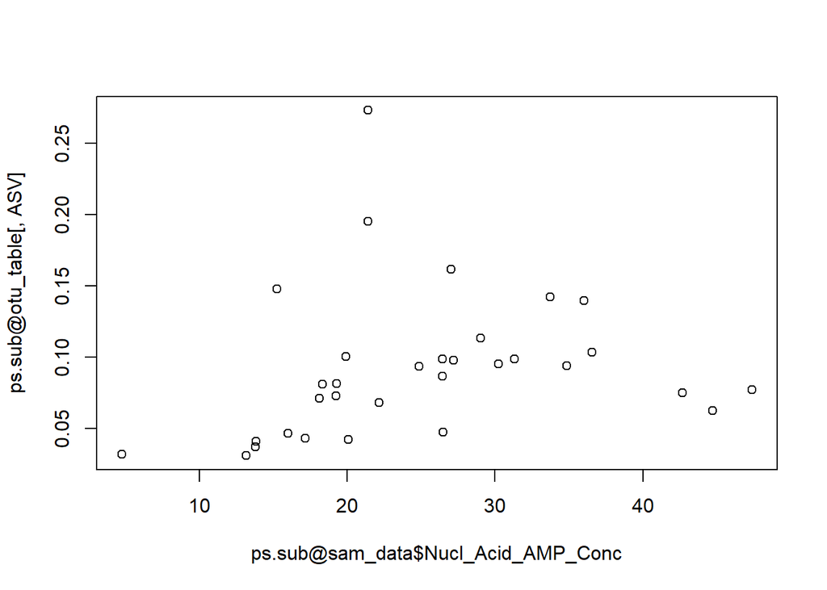

```r
plot(ps.sub@sam_data$Nucl_Acid_AMP_Conc,ps.sub@otu_table[,ASV], )
```

We see be a positive (rho=0.4630614) significant (p.value=0.0076102) association between the ASV and amplicon yield.

## 4.2 Multiple correlations

Lets use lapply to test all taxa in our subsetted phyloseq object.

```r
asvcor <- lapply(taxa_names(ps.sub), function(x) cor.test(ps.sub@sam_data$Nucl_Acid_AMP_Conc, method = "spearman",ps.sub@otu_table[,x], exact = F))
```

Lets extract the relevant statistics and merge these into a data frame.

```r
df <- data.frame(row.names=taxa_names(ps.sub),
                 rho=unname(unlist(lapply(asvcor, function(x) x$estimate))),
                 p.value=unlist(lapply(asvcor, function(x) x$p.value)))
```

## 4.3 p.adjust

Since we did 100 test we need to correct for multiple testing. Lets use BH correction to obtain the corrected p.values.

```r
df$p.adj <- p.adjust(df$p.value, method = "BH")
```

## 4.4 Table results

Since the ASVs are arbitrary labels lets include the taxonomy in the final table.

```r
df <- cbind(df, ps.sub@tax_table[rownames(df),])[order(df$p.value),]
DT::datatable(df)
```

|  | rho | p.value | p.adj | Kingdom | Phylum | Class | Order | Family | Genus | Species |
| --- | --- | --- | --- | --- | --- | --- | --- | --- | --- | --- |
| ASV_0236 | 0.639380330855732 | 8.16680501535106e-05 | 0.00816680501535106 | Bacteria | Lentisphaerae | Lentisphaeria | Victivallales | Victivallaceae | Victivallis | vadensis |
| ASV_2195 | -0.587911645787868 | 0.000402585861461823 | 0.0201292930730912 | Bacteria | Proteobacteria | Gammaproteobacteria | Pseudomonadales | Pseudomonadaceae | Pseudomonas |  |
| ASV_1213 | -0.542946193499426 | 0.00132330367665302 | 0.0441101225551008 | Bacteria | Firmicutes | Clostridia | Clostridiales | Lachnospiraceae |  |  |
| ASV_1370 | -0.530814415759873 | 0.00177460883327674 | 0.0443652208319186 | Bacteria | Firmicutes | Clostridia | Clostridiales | Lachnospiraceae | Anaerostipes | caccae |
| ASV_1333 | -0.51164931615947 | 0.00276111646423465 | 0.0552223292846929 | Bacteria | Firmicutes | Clostridia | Clostridiales | Lachnospiraceae |  |  |
| ASV_1582 | -0.483128561213889 | 0.00509507002756437 | 0.0691833881640041 | Bacteria | Firmicutes | Clostridia | Clostridiales | Clostridiaceae_1 | Clostridium_sensu_stricto_1 |  |
| ASV_1083 | -0.477172717271727 | 0.00575356454400641 | 0.0691833881640041 | Bacteria | Firmicutes | Clostridia | Clostridiales | Ruminococcaceae | Ruminiclostridium_6 |  |
| ASV_0593 | 0.475019170238938 | 0.00600894378042096 | 0.0691833881640041 | Bacteria | Bacteroidetes | Bacteroidia | Bacteroidales | Bacteroidaceae | Bacteroides |  |
| ASV_2331 | -0.466483282209679 | 0.00711868469802692 | 0.0691833881640041 | Bacteria | Proteobacteria | Gammaproteobacteria | Enterobacteriales | Enterobacteriaceae | Escherichia/Shigella | albertii/boydii/coli/dysenteriae/fergusonii/flexneri/sonnei/vulneris |
| ASV_1190 | -0.463830569474922 | 0.00749725612721648 | 0.0691833881640041 | Bacteria | Firmicutes | Clostridia | Clostridiales | Lachnospiraceae | Lachnoclostridium |  |

[output cut: 90 more lines]

## 4.5 Visualize correlations

It is good practice to visualize the results. Lets view the four significant ASVs using ggplot. To build the dataframe we can use `psmelt` function.

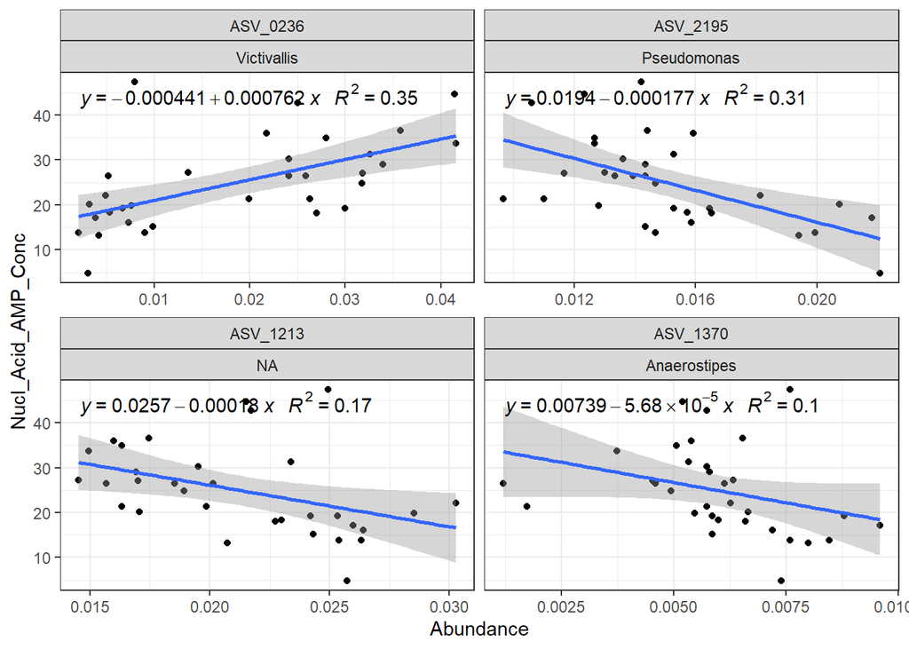

```r
taxa <- rownames(df)[order(df$p.value)[1:4]]
psm <- psmelt(prune_taxa(taxa, ps))
psm$OTU <- factor(psm$OTU, levels=taxa)

ggplot(psm, aes(y=Nucl_Acid_AMP_Conc, x=Abundance)) +
  theme_bw() +
  geom_point() +
  facet_wrap(~OTU*Genus, scales="free_x") +
  geom_smooth(method = "lm") +
  stat_poly_eq(formula = x ~ y,
               aes(label = paste(..eq.label.., ..rr.label.., sep = "~~~")),
               parse = TRUE) +
  NULL
```

We see that some of the taxa abundances are heavily biased by the amplicon yield, and relative abundance can change an order of magnitude. Unfortunately we do not know the causal factor for the variable amplicon yield and thus we cannot control for it. Therefor it is important to reduce the amount of batches in a study, and be extremely careful not have these possible factors confound the design!

# 5 Summary function

A summary function would look like

```r
covar_cor <- function(ps, taxa, covariate, p.adjust="BH"){
  # sum(is.na(get(covariate,ps@sam_data))) # check missing
  # class(get(covariate,ps@sam_data))=="numeric" # check numeric
  ps <- prune_taxa(taxa, ps)
  if(taxa_are_rows(ps)) otu_table(ps) <- otu_table(t(ps@otu_table), taxa_are_rows = F)
  asvcor <- lapply(taxa_names(ps), function(x) cor.test(get(covariate,ps@sam_data), method = "spearman",ps@otu_table[,x], exact = F))
  df <- data.frame(row.names=taxa_names(ps),
                 rho=unname(unlist(lapply(asvcor, function(x) x$estimate))),
                 p.value=unlist(lapply(asvcor, function(x) x$p.value)))
  df$p.adjust <- p.adjust(df$p.value, method = p.adjust)
  return (df)
}
```

## 5.1 summary function example

```r
df.example <- covar_cor(ps = ps, taxa = top100, covariate = "Nucl_Acid_AMP_Conc", p.adjust = "BH")
head(df.example)
```

```
##                  rho    p.value   p.adjust
## ASV_0006 -0.10797177 0.55639543 0.75169144
## ASV_2369 -0.41905024 0.01697542 0.08934429
## ASV_0014 -0.41222960 0.01905368 0.09073179
## ASV_2361  0.08576186 0.64071309 0.77194348
## ASV_1964 -0.18998717 0.29764615 0.48007444
## ASV_2003  0.19597875 0.28238240 0.47861424
```